# Data Scientist Technical Assessment

## Predicting Preschoolers' Test Scores Given mothers' Characteristics

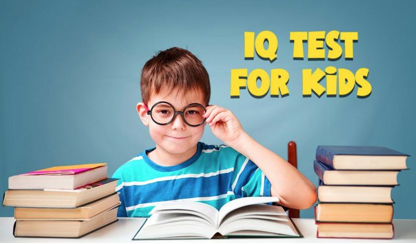

### Prepared by: Anuka Revi

# Part I - II: Data Cleaning & Data Transformation

**Please note while loading initial data in jupyter, error was produced detecting unusual characters. Double checking the text file, I noticed that line -- was not expected and didnot have any matching values. Removing the affected line did the trick and loaded data as expected. The new data I saved is uploaded on github as data_1.txt**

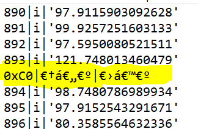

Initial text data had one column with all the variables in stacked format and corresponding values in a seperate column. I decided to expand those variables so that they would be columns of a new dataframe for better format and modelling.

Initially I split the column into obvious 3 separate columns that were connected with '|' to create a new df named "s" (split df)

```python
#import CSV
df=pd.read_csv("C://Users/arevi/Downloads/modified_data.csv")
print(df.head(5))

#split the only variable into 3 columns
s=df['count|variable|value'].str.split('|', expand=True)
s.columns=['Count', 'Variables', 'Values']
```

```
  count|variable|value
0           0|score|65
1           1|score|98
2           2|score|85
3           3|score|83
4          4|score|115
```

```python
#check the outcome after splittings - looks as expected
s.head(10)
```

|  | Count | Variables | Values |
| --- | --- | --- | --- |
| 0 | 0 | score | 65 |
| 1 | 1 | score | 98 |
| 2 | 2 | score | 85 |
| 3 | 3 | score | 83 |
| 4 | 4 | score | 115 |
| 5 | 5 | score | 98 |
| 6 | 6 | score | 69 |
| 7 | 7 | score | 106 |
| 8 | 8 | score | 102 |
| 9 | 9 | score | 95 |

Filtering unique variables from the *'Variables'* column and combining them, I created a new df of (434X5) size, each row corresponding to the unique observation with the following column variables:

- **child_IQ score**
- **mom_HS**
- **mom_age**
- **work_post_birth**
- **mom_IQ**

```python
#create df
df=pd.DataFrame([score['Values'].values, hs['Values'].values, age['Values'].values, iq['Values'].values, wrk['Values'].values])

#transpose the df
df=df.T

#change the column names according to the data dictionary
df.columns=['child_IQ', 'mom_HS', 'mom_age', 'mom_IQ', 'work_post_birth']


print(df.info())

#check the final result of df
print(df.head(10))
```

```
<class 'pandas.core.frame.DataFrame'>
RangeIndex: 434 entries, 0 to 433
Data columns (total 5 columns):
 #   Column           Non-Null Count  Dtype
---  ------           --------------  -----
 0   child_IQ         434 non-null    object
 1   mom_HS           434 non-null    object
 2   mom_age          434 non-null    object
 3   mom_IQ           434 non-null    object
 4   work_post_birth  434 non-null    object
dtypes: object(5)
memory usage: 17.1+ KB
None
  child_IQ mom_HS mom_age              mom_IQ work_post_birth
0       65      1      27  '121.117528602603'               4
1       98      1      25  '89.3618817100663'               4
2       85      1      27  '115.443164881725'               4
3       83      1      25  '99.4496394360723'               3
4      115      1      27  '92.7457099982118'               4
5       98      0      18  '107.901837758501'               1
6       69      1      20  '138.893106071162'               4
7      106      1      23  '125.145119475328'               3
8      102      1      24  '81.6195261789843'               1
9       95      1      19  '95.0730686206496'               1
```

## Variable Types

Please note while format looks ok, all the variables appear as objects. It's obvious that **mom_IQ, mom_age, and child_IQ** need to be numeric variables.

After detecting & remediating the issue with mom_IQ variable, where values where stored in single quotation marks, all three variables were converted into numeric data type.

```python
#convert those 3 variables to numeric now
df["mom_IQ"]=pd.to_numeric(df["mom_IQ"], downcast="float")
df["mom_age"]=pd.to_numeric(df["mom_age"], downcast="float")
df["child_IQ"]=pd.to_numeric(df["child_IQ"],downcast="float")



#lambda for rounding
df["mom_IQ"]=df["mom_IQ"].map(lambda x: round(x, 2))
df["child_IQ"]=df["child_IQ"].map(lambda x: round(x, 2))

#check result ost round
#df["mom_IQ"].head(5)
#df["child_IQ"].head(5)
```

[output not shown]

```python
#check uniqe values in mom_HS col - looks ok as 1,0 boolean
print(df.mom_HS.unique())

#convert work_post_birth to categorical variable
df["work_post_birth"] = df["work_post_birth"].astype("category")

df.work_post_birth.unique()

#check variable types now
print(df.info())

df.head(10)
```

```
['1' '0']
<class 'pandas.core.frame.DataFrame'>
RangeIndex: 434 entries, 0 to 433
Data columns (total 5 columns):
 #   Column           Non-Null Count  Dtype
---  ------           --------------  -----
 0   child_IQ         434 non-null    float64
 1   mom_HS           434 non-null    object
 2   mom_age          434 non-null    float32
 3   mom_IQ           434 non-null    float64
 4   work_post_birth  434 non-null    category
dtypes: category(1), float32(1), float64(2), object(1)
memory usage: 12.6+ KB
None
```

|  | child_IQ | mom_HS | mom_age | mom_IQ | work_post_birth |
| --- | --- | --- | --- | --- | --- |
| 0 | 65.0 | 1 | 27.0 | 121.12 | 4 |
| 1 | 98.0 | 1 | 25.0 | 89.36 | 4 |
| 2 | 85.0 | 1 | 27.0 | 115.44 | 4 |
| 3 | 83.0 | 1 | 25.0 | 99.45 | 3 |
| 4 | 115.0 | 1 | 27.0 | 92.75 | 4 |
| 5 | 98.0 | 0 | 18.0 | 107.90 | 1 |
| 6 | 69.0 | 1 | 20.0 | 138.89 | 4 |
| 7 | 106.0 | 1 | 23.0 | 125.15 | 3 |
| 8 | 102.0 | 1 | 24.0 | 81.62 | 1 |
| 9 | 95.0 | 1 | 19.0 | 95.07 | 1 |

Now we have a cleaner data, with 3 numerical variables ( mom_age, mom_IQ, child_IQ), 1 boolean object, encoded with 1 & 0 (mom_HS) *note this will later be converted into numeric with one-hot encoding for regression analysis*, and 1 categorical object (work_post_birth). We will move to part 2 -Explanatory Data Analysis

# Part III : EDA

```python
#get basic statistics of numerical variables
print(df.describe())

#check for missing values
print(df.isnull().sum())
```

```
         child_IQ     mom_age      mom_IQ
count  434.000000  434.000000  434.000000
mean    86.797235   22.785715  100.000092
std     20.410688    2.701069   15.000042
min     20.000000   17.000000   71.040000
25%     74.000000   21.000000   88.660000
50%     90.000000   23.000000   97.920000
75%    102.000000   25.000000  110.272500
max    144.000000   29.000000  138.890000
child_IQ           0
mom_HS             0
mom_age            0
mom_IQ             0
work_post_birth    0
dtype: int64
```

## Univariate Analysis for Numerica Data

### Boxplots & Histograms for child_IQ: visual inspection for outliers and normality

Based on boxplots and histograms below, the data doesnot seem to be suffering much from outliers. Also we have no missing values; Both IQ scores are fairly symmetrical, their original skewness level <|0.5|. Log transforming mom' IQ scores made data more normal, but it didnot help for child_IQ scores, thus I would leave it untouched for further analysis.

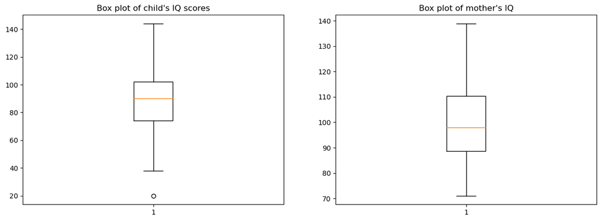

```python
#explore outliers of variables mom_IQ and child_IQ

plt.figure(figsize=(15,5))

plt.subplot(1,2,1)
plt.boxplot(df["child_IQ"])
plt.title("Box plot of child's IQ scores")


plt.subplot(1,2,2)
plt.boxplot(df["mom_IQ"])
plt.title("Box plot of mother's IQ")


plt.show()
```

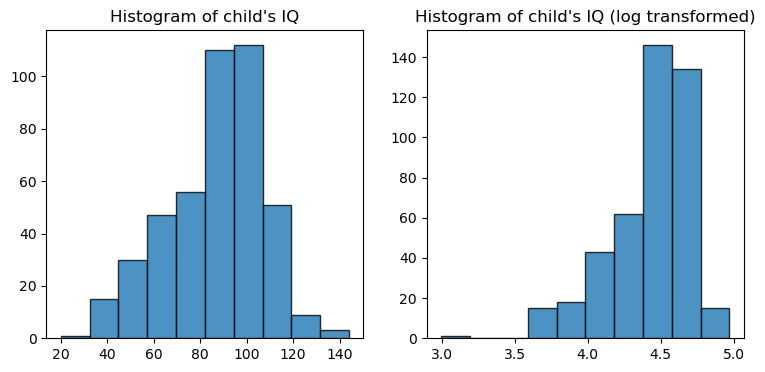

```
DescribeResult(nobs=434, minmax=(20.0, 144.0), mean=86.79723502304148, variance=416.59620480837805, skewness=-0.46056725349871636, kurtosis=-0.17238157048610692)
DescribeResult(nobs=434, minmax=(2.995732273553991, 4.969813299576001), mean=4.430854769738374, variance=0.07273309971277821, skewness=-1.2069758778592803, kurtosis=1.8435785014171095)
```

```python
#lets see histograms
plt.figure(figsize=(9,4))

plt.subplot(1,2,1)
plt.hist(df["child_IQ"], edgecolor="black", alpha=0.8)
plt.title("Histogram of child's IQ")


plt.subplot(1,2,2)
plt.hist(np.log(df["child_IQ"]), edgecolor="black", alpha=0.8)
plt.title("Histogram of child's IQ (log transformed)")

plt.show()

#normality test
print(stats.describe(df["child_IQ"]))

#log transfor the data
print(stats.describe(np.log(df["child_IQ"])))
```

### Histogram & some statistics for mother's_IQ

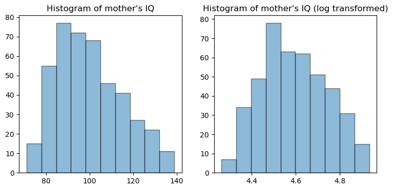

```
DescribeResult(nobs=434, minmax=(71.04, 138.89), mean=100.00009216589861, variance=225.00124895222493, skewness=0.46672554986827874, kurtosis=-0.5780168531919916)
DescribeResult(nobs=434, minmax=(4.2632430986839145, 4.9336822529281275), mean=4.594190958848788, variance=0.021824240029371698, skewness=0.20328658408695363, kurtosis=-0.7655657911207818)
```

```python
#lets see histograms
plt.figure(figsize=(9,4))

#raw mom_IQ Data
plt.subplot(1,2,1)
plt.hist(df["mom_IQ"], edgecolor="black", alpha=0.5)
plt.title("Histogram of mother's IQ")


plt.subplot(1,2,2)
plt.hist(np.log(df["mom_IQ"]), edgecolor="black", alpha=0.5)
plt.title("Histogram of mother's IQ (log transformed)")

plt.show()

#normality
print(stats.describe(df["mom_IQ"]))

#log transformed stats
print(stats.describe(np.log(df["mom_IQ"])))
```

## Univariate Analysis for Categorical Data

### Work_post_birth

Looking at the categorical variable work_post_birth below, it's interesting to see the distribution of the bar chart. According to the data dictionary we know that w=4 represents mothers who worked full time in first year of child's life and majory of mothers did that, followed by w=2, mothers worked second or third year in childs life, then w=1 - mother didnot work in the first 3 years of child's life, and lastly and w=3 - mother worked part-time in the first year of child's life.

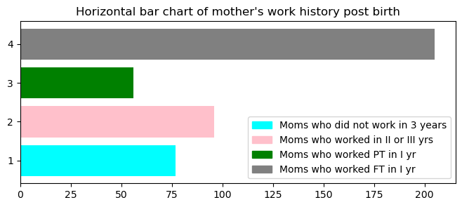

```python
#visuaize categorical variables
import matplotlib.patches as mpatches


plt.figure(figsize=(8,3))
plt.barh(df.groupby("work_post_birth")["work_post_birth"].count().index,
         df.groupby("work_post_birth")["work_post_birth"].count(),
         color=["cyan", "pink", "green", "gray"])
plt.title("Horizontal bar chart of mother's work history post birth")
#add legend

cyan_patch = mpatches.Patch(color='cyan', label='Moms who did not work in 3 years')
pink_patch = mpatches.Patch(color='pink', label='Moms who worked in II or III yrs')
green_patch = mpatches.Patch(color='green', label='Moms who worked PT in I yr')
gray_patch = mpatches.Patch(color='gray', label='Moms who worked FT in I yr')
plt.legend(handles=[cyan_patch, pink_patch, green_patch, gray_patch])


plt.show()
```

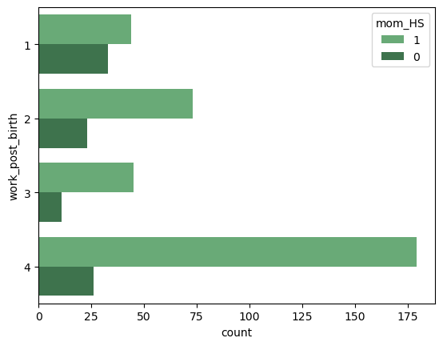

```python
# mom's post birth history for HS vs no HS holders
sns.countplot(y="work_post_birth", hue="mom_HS", data=df, palette="Greens_d")
plt.show()
```

The below graph also shows barplots of average child IQ score for mothers with HS v. no HS completion and with varied levels of mother's post birth work experience.

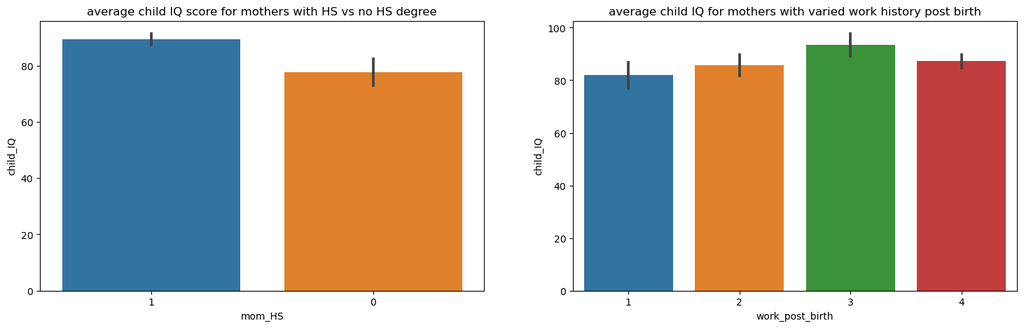

```python
plt.figure(figsize=(18,5))

plt.subplot(1,2,1)
sns.barplot(df["mom_HS"], df["child_IQ"])
plt.title("average child IQ score for mothers with HS vs no HS degree")

plt.subplot(1,2,2)
sns.barplot(df["work_post_birth"], df["child_IQ"])
plt.title("average child IQ for mothers with varied work history post birth")


plt.show()
```

## Multivariate Analysis: Exploring Relationship between Target and Explanatory Variables

After visualizing the distribution of numerical variables as well as some statistics for categoricals columns, I would like to explore relationship between score (regressand) and 2 numerical variables (mom_age & mom_IQ) using scatterplot

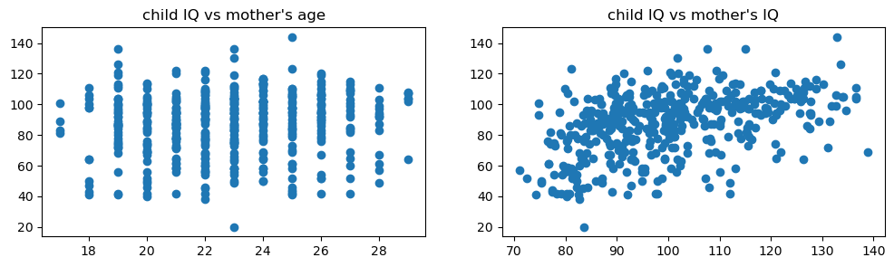

```python
plt.figure(figsize=(12,3))

plt.subplot(1,2,1)
plt.scatter(df["mom_age"], df["child_IQ"])
plt.title("child IQ vs mother's age")



plt.subplot(1,2,2)
plt.scatter(df["mom_IQ"], df["child_IQ"])
plt.title("child IQ vs mother's IQ")


plt.show()
```

```python
#get correlation matrix

print(df.corr())
```

```
          child_IQ   mom_age    mom_IQ
child_IQ  1.000000  0.091998  0.448276
mom_age   0.091998  1.000000  0.091608
mom_IQ    0.448276  0.091608  1.000000
```